# Visualización de la Información

Oscar Centeno Mora

El presente tema expone la representación visual mediantes gráficos, nube de palabras y otros elementos. Se abordarán los puntos:

- ¿Cuál método visual utilizar?
- Visualización clásica.
- ggplot.
- Plotly.
- sunburstR
- highcharter
- Otras librerías en R….

Al finalizar la sesión podrá conocer los principales **paquetes** - *librerías* de visualización de la información en R.

[figure not shown]

## Formas de visualizar

[figure not shown]

Existen muchas, muchíiiiiiiisimas formas para visualizar la información. ¿Qué deberíamos elegir? Esto depende de lo que queramos hacer.

- Barras verticales / horizontales.
- Histogramas.
- Lineas.
- Áreas.
- Disperción.
- Circular.
- Anillos o donas.
- Proyección solar.
- Bloques.
- Radar.
- Mapas.
- Nube de palabras.
- etc…

Y la lista podría seguir…

Al analizar datos nos hacemos la pregunta: ¿qué debería utlizar para visualr esta información?

Acá les presento una guía resumida:

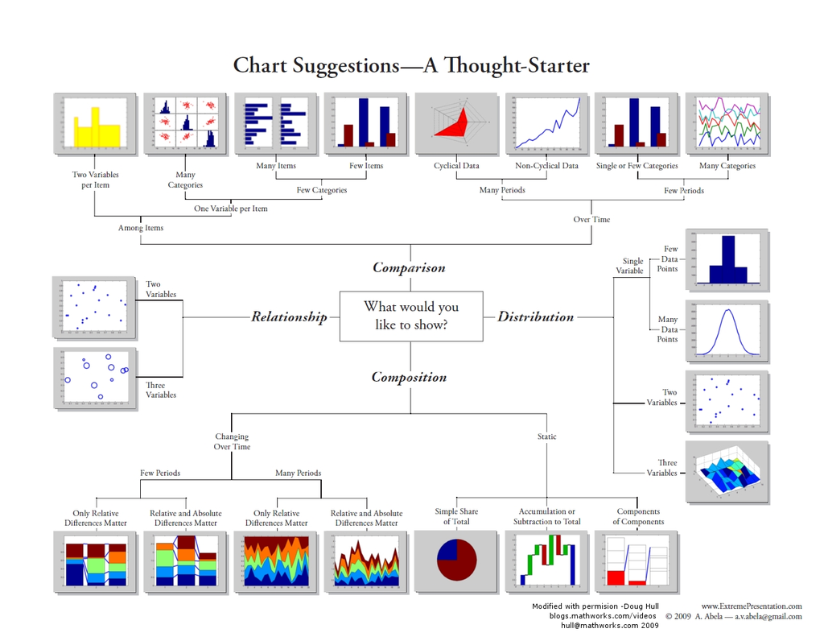

¿Y para visual el texto que utilizamos?

Trataremos de cubrir esta pregunta más adelante, sin embargo adentarse en el mundo de la visualización es descubrir que existe una gama mucho más amplia, versatil e interesante a la hora de visualizar nuestra data.

## Clásico

[figure not shown]

## lattice

[figure not shown]

El paquete latice fue la primera evolución en la mejora visual de los datos. Dentro de los principales gráficos se pueden realizar:

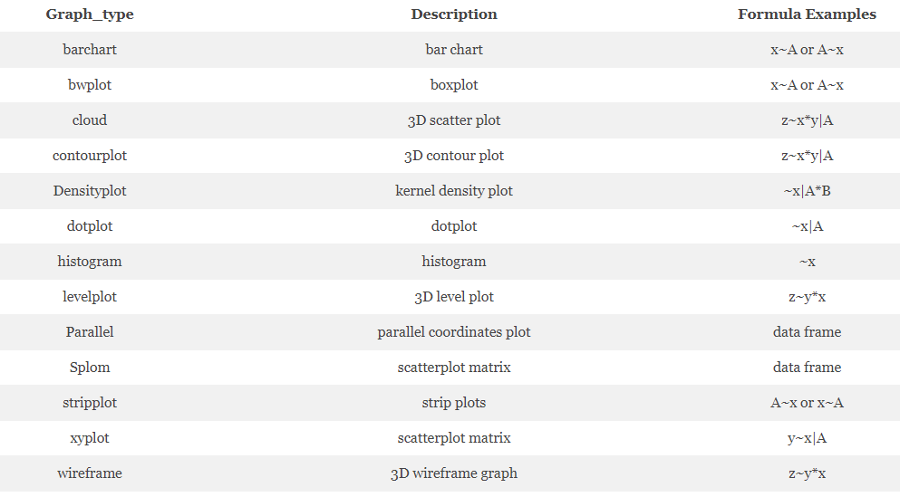

Las funciones utilizadas para poder desarrollar dichos gráficos son las siguientes:

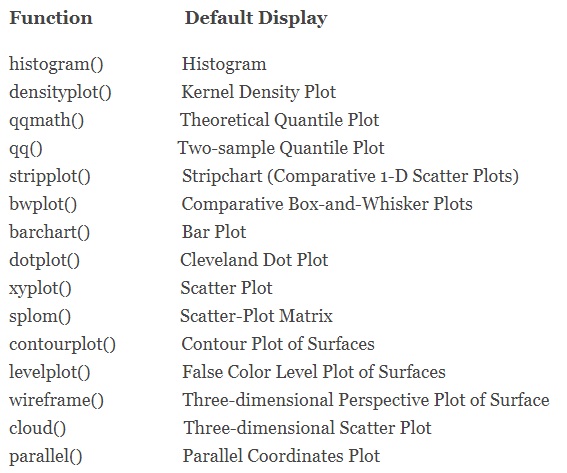

Veamos algunos ejemplos

#### Gráfico de densidad

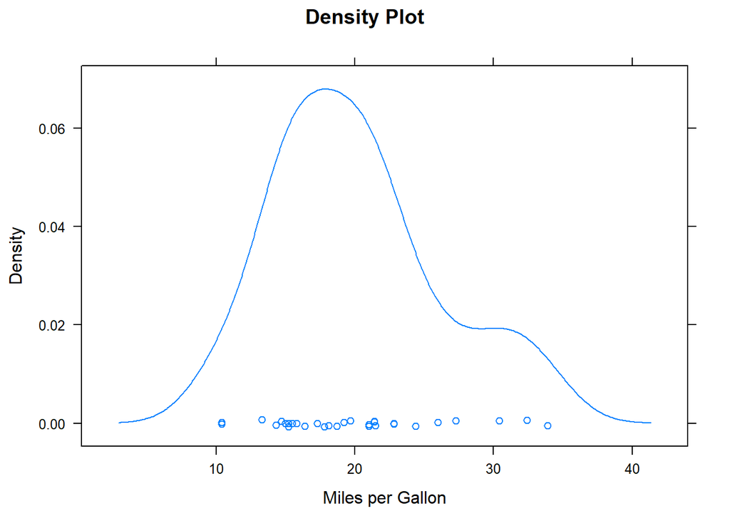

```r
densityplot(~mpg,
   main="Density Plot",
   xlab="Miles per Gallon")
```

#### Gráfico de densidad por grupo

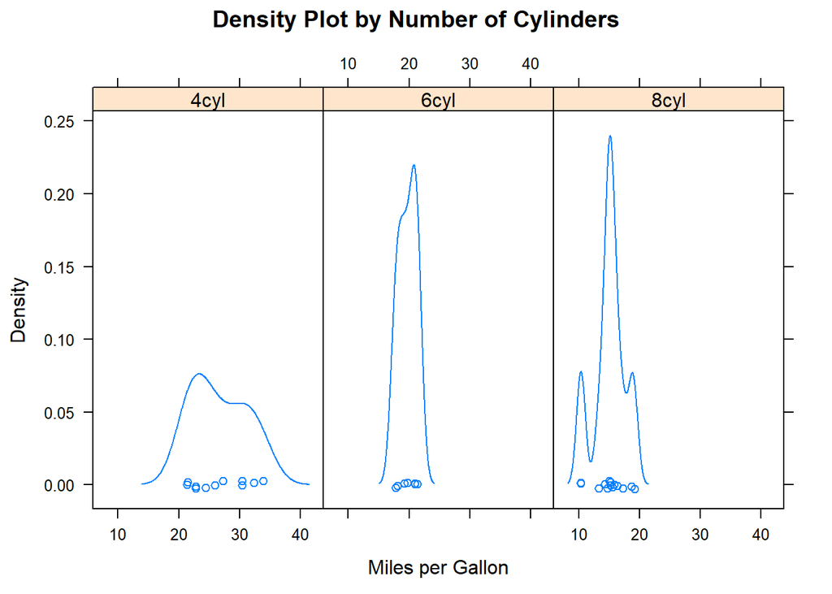

```r
densityplot(~mpg|cyl.f,
   main="Density Plot by Number of Cylinders",
   xlab="Miles per Gallon")
```

#### Agrupación apilada

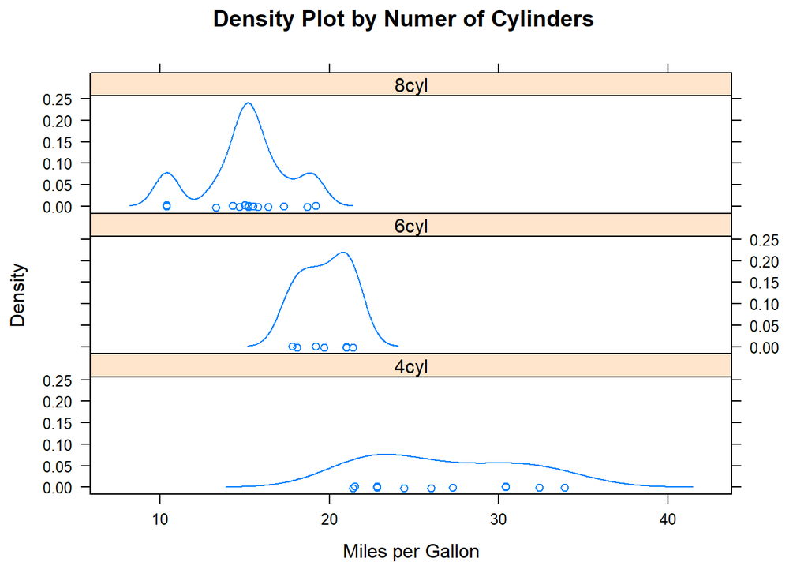

```r
densityplot(~mpg|cyl.f,
   main="Density Plot by Numer of Cylinders",
   xlab="Miles per Gallon",
   layout=c(1,3))
```

#### Disperción según factores

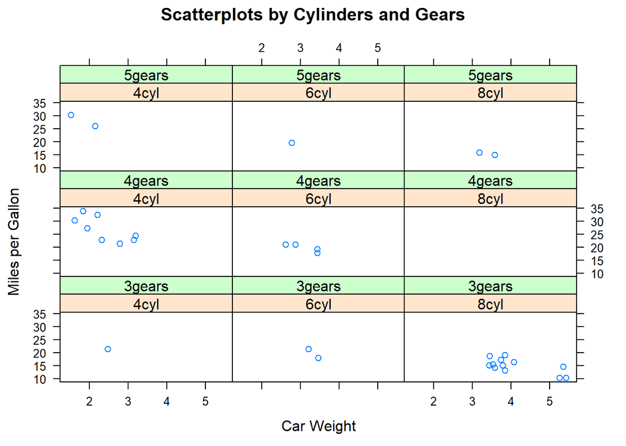

```r
xyplot(mpg~wt|cyl.f*gear.f,
   main="Scatterplots by Cylinders and Gears",
   ylab="Miles per Gallon", xlab="Car Weight")
```

#### Dispersión 3D

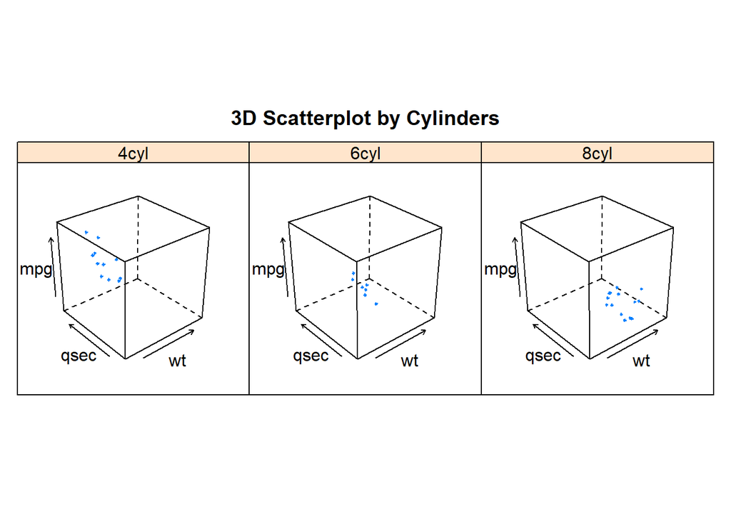

```r
cloud(mpg~wt*qsec|cyl.f,
   main="3D Scatterplot by Cylinders")
```

#### Correlograma de las variables

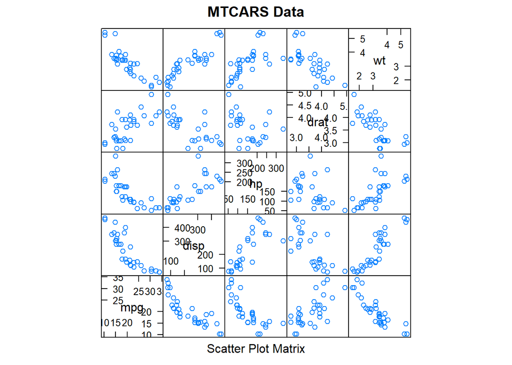

```r
splom(mtcars[c(1,3,4,5,6)],
   main="MTCARS Data")
```

Pues, es mucho más atractivo que los gráficos “clásicos”, sin embargo el paquete **ggplot** trajo una mejora considerable a lo que la visualización de la información respecta.

## ggplot2

[figure not shown]

## ggchart

[figure not shown]

## Plotly

[figure not shown]

## dygraph

[figure not shown]

## sunburstR

[figure not shown]

## highcharter

[figure not shown]

## REF

[figure not shown]

Véase los siguientes sitios de referencia

### lattice

https://www.statmethods.net/advgraphs/trellis.html http://www.sthda.com/english/wiki/lattice-graphs http://www.sthda.com/english/wiki/lattice-graphs https://www.rdocumentation.org/packages/lattice/versions/0.20-41 https://www.dummies.com/programming/r/how-to-create-a-lattice-plot-in-r/ https://data-flair.training/blogs/r-lattice-package/ https://stat.ethz.ch/R-manual/R-devel/library/lattice/html/Lattice.html http://www.datavis.ca/courses/RGraphics/R-Graphics3.pdf

### ggplot2

https://www.r-graph-gallery.com/ggplot2-package.html http://r-statistics.co/ggplot2-Tutorial-With-R.html https://ggplot2.tidyverse.org/ https://www.statmethods.net/advgraphs/ggplot2.html https://rpubs.com/daniballari/ggplot http://tutorials.iq.harvard.edu/R/Rgraphics/Rgraphics.html https://www.rdocumentation.org/packages/ggplot2/versions/3.3.2 https://swcarpentry.github.io/r-novice-gapminder-es/08-plot-ggplot2/ https://datacarpentry.org/R-ecology-lesson/04-visualization-ggplot2.html

### ggchart

https://github.com/thomas-neitmann/ggcharts https://www.rdocumentation.org/packages/ggcharts/versions/0.2.1 https://rdrr.io/cran/ggcharts/ https://tereom.github.io/tutoriales/R_intro_visualizacion.html

### Plotly

https://plotly.com/r/ https://plotly-r.com/ https://www.rdocumentation.org/packages/plotly/versions/4.9.2.1 https://www.neonscience.org/plotly https://www.it-swarm.dev/es/r-plotly/ https://github.com/ropensci/plotly https://rdrr.io/cran/plotly/man/ggplotly.html https://www.htmlwidgets.org/showcase_plotly.html https://www.r-bloggers.com/introduction-to-interactive-graphics-in-r-with-plotly/

### dygraph

https://rstudio.github.io/dygraphs/ https://www.htmlwidgets.org/showcase_dygraphs.html https://github.com/rstudio/dygraphs https://blog.rstudio.com/2015/04/14/interactive-time-series-with-dygraphs/ https://rdrr.io/cran/dygraphs/man/dySeries.html https://rpubs.com/Da_As_Kumi/561455 https://bookdown.org/kochiuyu/Technical-Analysis-with-R/dygraphs-package.html http://www.imsbio.co.jp/RGM/R_function_list?package=dygraphs&init=true https://www.r-bloggers.com/how-to-plot-with-dygraphs-exercises/

### sunburstR

http://rstudio-pubs-static.s3.amazonaws.com/495237_5336f47cb4df483f8f2780cd92066449.html https://www.data-to-viz.com/graph/sunburst.html https://github.com/timelyportfolio/sunburstR https://www.rdocumentation.org/packages/sunburstR/versions/2.1.3/topics/sunburst https://rdrr.io/cran/sunburstR/src/R/sunburst.R

### highcharter

https://rstudio-pubs-static.s3.amazonaws.com/320413_6ab300527e8548b1a3cbd0d4c6200fcc.html https://www.highcharts.com/blog/tutorials/highcharts-for-r-users/ https://towardsdatascience.com/exploring-highcharts-in-r-f754143efda7 https://github.com/jbkunst/highcharter https://www.htmlwidgets.org/showcase_highcharts.html https://rdrr.io/cran/highcharter/man/hc_legend.html https://rpubs.com/jbkunst/highcharter http://uribo.github.io/rpkg_showcase/graphics/highcharter.html